# Análise dos Gastos de Deputados

Valter Lucena

03 de setembro de 2018

```r
library(tidyverse)
library(here)
theme_set(theme_minimal())
```

# Dados

Esta análise objetiva entender melhor o uso da [Cota ara o Exercício da Atividade Parlamentar (CEAP)](http://www2.camara.leg.br/transparencia/acesso-a-informacao/copy_of_perguntas-frequentes/cota-para-o-exercicio-da-atividade-parlamentar) dos deputados federais brasileiros.

Inicialmente, vamos importar nossos dados e ver sobre quais variáveis temos informações.

```r
# lê os dados
gastos <- read_csv(here("data/dadosCEAP.csv"),
                   progress = FALSE)

# mostra o nome das variáveis disponíveis
gastos %>% names()
```

```
##  [1] "nomeParlamentar" "idCadastro"      "sgUF"
##  [4] "sgPartido"       "tipoDespesa"     "especDespesa"
##  [7] "fornecedor"      "CNPJCPF"         "tipoDocumento"
## [10] "dataEmissao"     "valorDocumento"  "valorGlosa"
## [13] "valorLíquido"
```

Na base de dados, cada observação refere-se à uma despesa de algum deputado. Para visualizar melhor, futuramente, esses dados, vamos acrescentar à eles a região de cada estado que elegeu o parlamentar.

```r
# adiciona uma nova variável contendo a região à qual cada estado pertence
gastos <- gastos %>%
  mutate(regiao = case_when(
    sgUF %in% c("AC", "AP", "AM", "PA", "RO", "RR", "TO") ~ "Norte",
    sgUF %in% c("AL", "BA", "CE", "MA", "PB", "PE", "PI", "RN", "SE") ~ "Nordeste",
    sgUF %in% c("DF", "GO", "MT", "MS") ~ "Centro-Oeste",
    sgUF %in% c("ES", "MG", "RJ", "SP") ~ "Sudeste",
    sgUF %in% c("PR", "RS", "SC") ~ "Sul"
  ))
```

# Perguntas

## Quais são os deputados que gastaram mais dinheiro da CEAP? Quais são os mais econômicos?

Primeiramente, vamos ver quais os deputados que mais gastam. Como nossa base de dados é muito extensa, vamos selecionar apenas os 10 deputados que gastam mais dinheiro da CEAP.

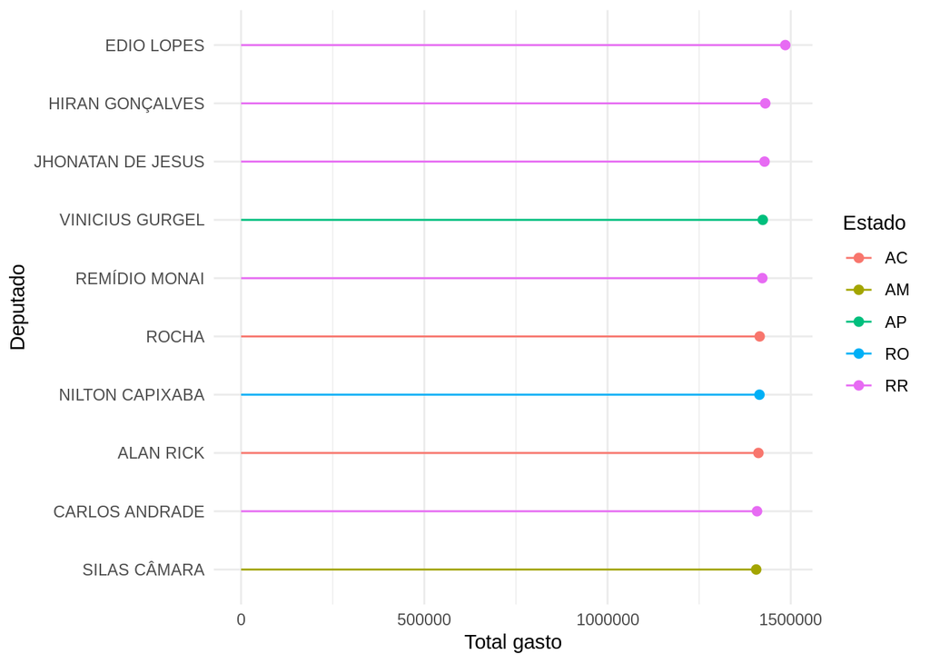

```r
gastos %>%
  group_by(nomeParlamentar, sgUF) %>%
  summarise(total = sum(valorLíquido)) %>% # total gasto por um deputado
  filter(total >= 0) %>%
  ungroup() %>%
  arrange(-total) %>% # ordena de forma descrescente
  slice(1:10) %>% # seleciona os 10 maiores valores
  na.omit() %>%  # omite valores inexistentes
  ggplot(aes(x = reorder(nomeParlamentar, total),
             y = total,
             colour = sgUF)) +
  geom_point(size = 2) +
  geom_segment(aes(x = reorder(nomeParlamentar, total),
                   xend = reorder(nomeParlamentar, total),
                   y = 0,
                   yend = total)) +
  coord_flip() +
  guides(color = guide_legend("Estado")) +
  labs(y = "Total gasto",
       x = "Deputado")
```

Vejamos, agora, quais os que menos gastam. Novamente, selecionaremos apenas um “bottom 10” de deputados.

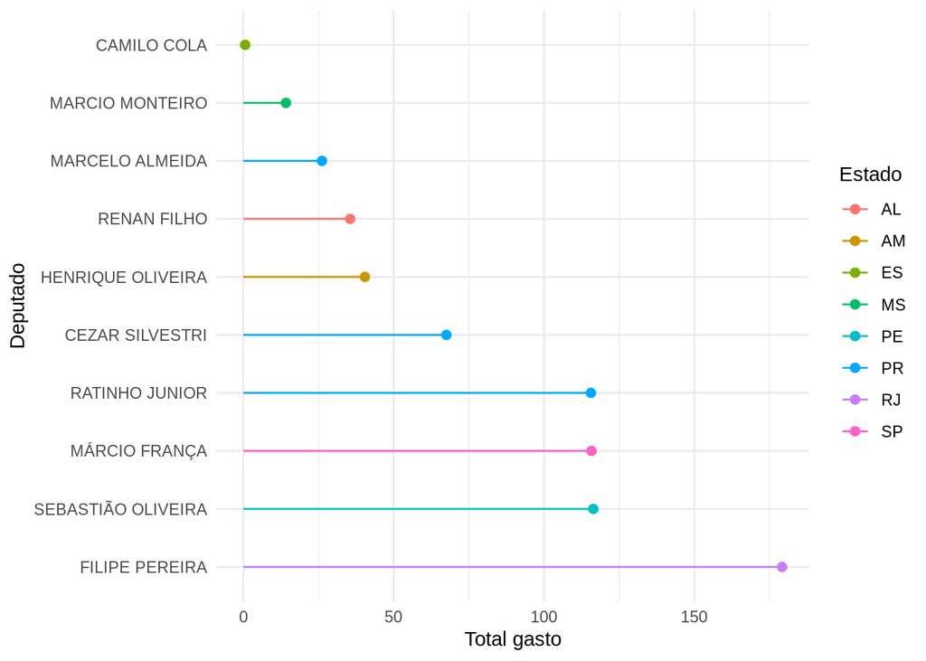

```r
gastos %>%
  group_by(nomeParlamentar, sgUF) %>%
  summarise(total = sum(valorLíquido)) %>% # total gasto por um deputado
  filter(total >= 0) %>%
  ungroup() %>%
  arrange(total) %>% # ordena de forma crescente
  slice(1:10) %>% # seleciona os 10 menores valores
  na.omit() %>% # omite valores inexistentes
  ggplot(aes(x = reorder(nomeParlamentar, -total),
             y = total,
             colour = sgUF)) +
  geom_point(size = 2) +
  geom_segment(aes(x = reorder(nomeParlamentar, -total),
                   xend = reorder(nomeParlamentar, -total),
                   y = 0,
                   yend = total)) +
  coord_flip() +
  guides(color = guide_legend("Estado")) +
  labs(y = "Total gasto",
       x = "Deputado")
```

Sabendo que o total utilizado nos gráficos refere-se à soma de todas as despesas associadas à um deputado, é importante salientar aqui a enorme diferença entre o total gasto pelos deputados que mais gastam e o total dos que menos gastam.

## Quais os estados cujos deputados gastam mais no exterior? Quais os estados cujos deputados gastam menos no exterior?

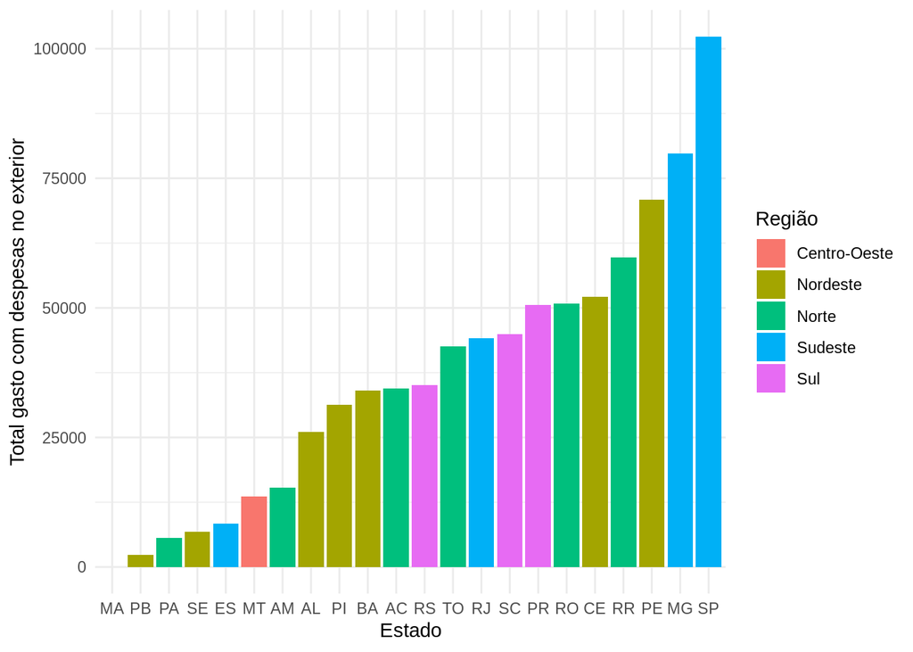

```r
gastos %>%
  filter(tipoDocumento == 2) %>% # seleciona apenas observacoes referentes à gastos no exterior
  group_by(sgUF, regiao) %>%
  summarise(total = sum(valorLíquido)) %>% # calcula o total gasto por estado
  ggplot(aes(x = reorder(sgUF, total),
             y = total,
             fill = regiao)) +
  geom_col(position = position_identity()) +
  guides(fill = guide_legend("Região")) +
  labs(y = "Total gasto com despesas no exterior",
       x = "Estado")
```

Entre os estados que mais gastam no exterior, encontram-se São Paulo, Minas Gerais, Pernambuco, Roraima e Ceará. Entre os que menos gastam, estão Maranhão, Paraíba, Pará, Sergipe e Espírito Santo. Vemos aqui que as regiões Norte, Nordeste e Sudeste contemplam ambos os extremos do gráfico.

## Quais os partidos cujos parlamentares mais usam CEAP no estado da Paraíba? Quais são os que menos usam? Mesmas perguntas considerando valores em R$.

```r
partidos <- gastos %>%
  filter(sgUF %in% c("PB")) %>% # seleciona apenas dados da Paraíba
  group_by(sgPartido) %>%
  summarise(total = sum(valorLíquido), # soma o total gasto por partido
            quantidade = n()) # conta quantas despesas (linhas) existem para cada partido
```

Considerando a quantidade de gastos, temos:

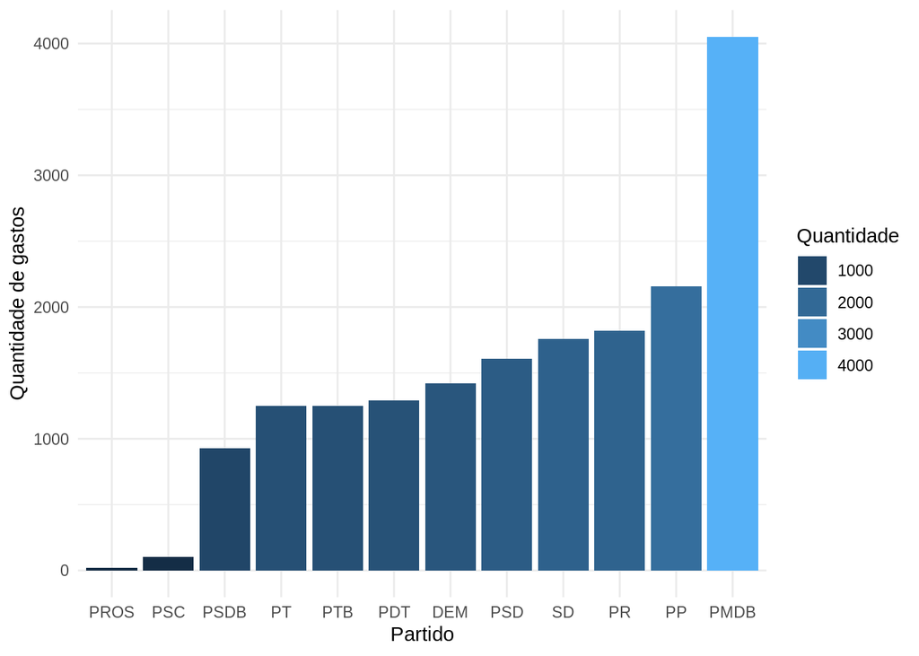

```r
partidos %>%
  ggplot(aes(x = reorder(sgPartido, quantidade),
             y = quantidade,
             fill = quantidade)) +
  geom_col() +
  guides(fill = guide_legend("Quantidade")) +
  labs(y = "Quantidade de gastos",
       x = "Partido")
```

O PMDB lidera o ranking aqui, com aproximadamente 4000 gastos utilizando a CEAP. Vejamos agora o que acontece se considerarmos o valor gasto.

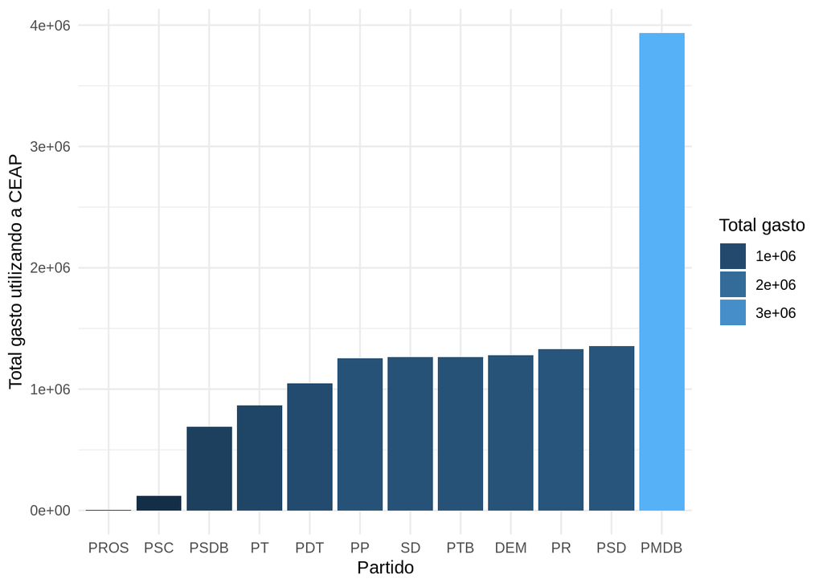

```r
partidos %>%
  ggplot(aes(x = reorder(sgPartido, total),
             y = total,
             fill = total)) +
  geom_col() +
  guides(fill = guide_legend("Total gasto")) +
  labs(y = "Total gasto utilizando a CEAP",
       x = "Partido")
```

Considerando o valor gasto pelos deputados, novamente o PMDB lidera o ranking, gastando no total quase 4 milhões de reais da CEAP.

## Quais os deputados que mais ultrapassam o limite de CEAP do seu estado?

Para responder essa pergunta, precisaremos dos dados do limite mensal da CEAP para cada estado.

```r
limiteMensal <- read_csv(here("data/limiteMensalCEAP.csv")) %>%
  select(sgUF = UF,
         limite_mensal = limite_mensal) # modifica o nome das variaveis para que o join seja possível

gastos <- left_join(gastos, limiteMensal) %>% # une as duas bases de dados com base no estado
  mutate(mes = months(as.Date(dataEmissao)), # cria uma nova coluna com o mes de uma despesa
         ano = format(dataEmissao, "%Y")) # cria uma nova coluna com o ano de uma despesa
```

Vejamos, agora, quais os deputados que mais ultrapassam esse limite.

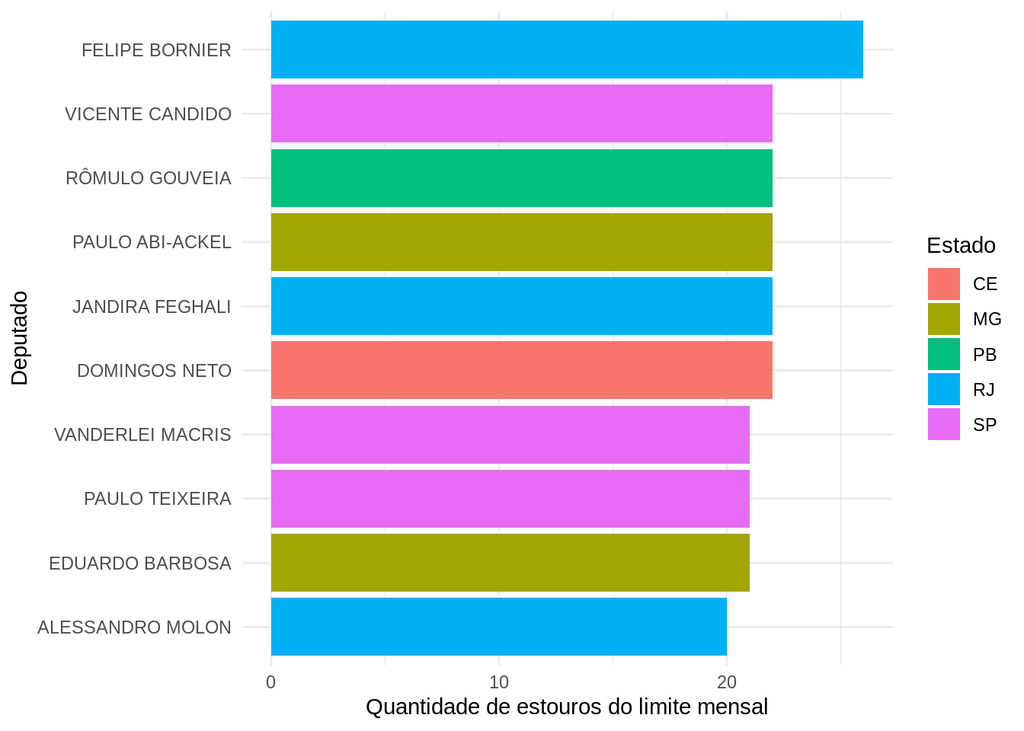

```r
gastos %>%
  group_by(nomeParlamentar,
           mes,
           ano,
           limite_mensal,
           sgUF) %>%
  filter(valorLíquido >= 0) %>%
  summarise(total = sum(valorLíquido)) %>% # calcula o total gasto em um mes de um determinado ano por um deputado
  filter(total > limite_mensal) %>% # mantém as observações onde o total excede o limite mensal de cada estado
  ungroup() %>%
  group_by(nomeParlamentar, sgUF) %>%
  summarise(estouros = n()) %>% # contabiliza a quantidade de vezes em que um deputado ultrapassa o limite mensal estipulado
  ungroup() %>%
  arrange(-estouros) %>% # ordena a quantidade de estouros de forma descrescente
  slice(1:10) %>% # seleciona os 10 maiores valores
  ggplot(aes(x = reorder(nomeParlamentar, estouros),
             y = estouros,
             fill = sgUF)) +
  geom_col() +
  coord_flip() +
  guides(fill = guide_legend("Estado")) +
  labs(y = "Quantidade de estouros do limite mensal",
       x = "Deputado")
```

O deputado Felipe Bornier lidera o ranking como o deputado que mais ultrapassa o limite da CEAP de seu estado, que é o Rio de Janeiro. Todos os deputados do ranking são das regiões Sudeste e Nordeste, que são representadas por 8 e 2 deputados, respectivamente.

## Quais estados cujos parlamentares gastam mais com passagens aéreas?

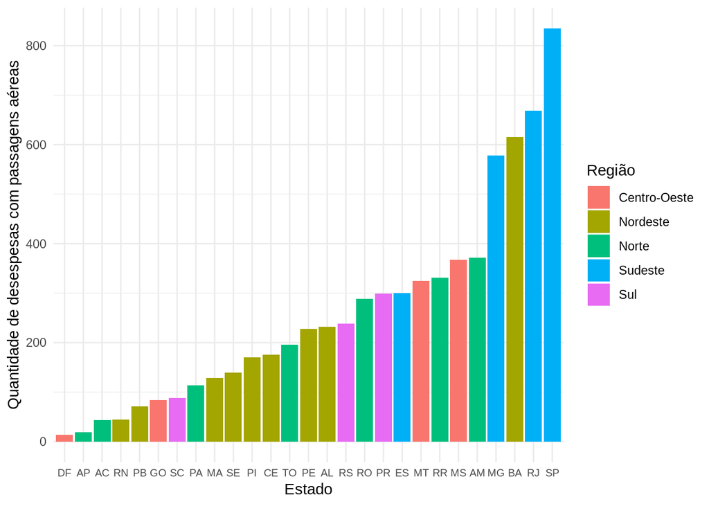

```r
gastos %>%
  filter(tipoDespesa %in% c("PASSAGENS AÉREAS")) %>% # mantém somente as observações referentes à despesas com passagens aéreas
  group_by(sgUF, regiao) %>%
  summarise(total = n()) %>% # calcula a quantidade de despesas com passagens aéreas de cada estado
  arrange(total) %>% # ordena o valor calculado de forma crescente
  na.omit() %>% # omite observacoes inexistentes
  ggplot(aes(x = reorder(sgUF, total),
             y = total,
             fill = regiao)) +
  geom_col() +
  theme(axis.text.x = element_text(size = 7.5)) +
  guides(fill = guide_legend("Região")) +
  labs(y = "Quantidade de desespesas com passagens aéreas",
       x = "Estado")
```

Pelo gráfico, podemos observar que São Paulo é o estado cujos deputados mais gastam com passagens aéreas. É interessante observar aqui que todos os estados da região Sudeste estão presentes neste top 10.

## Escolha três partidos e responda: Quais são os tipos de despesa mais utilizados no uso da CEAP pelos deputados desses partidos? Mesma pergunta considerando valores em R$.

Os partidos escolhidos foram o PMDB, DEM e PSDB.

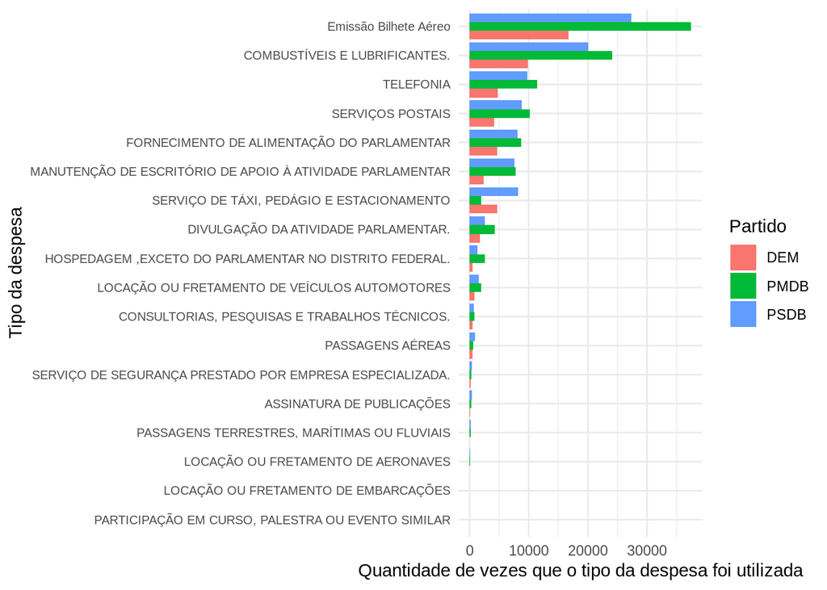

```r
gastos %>%
  filter(sgPartido %in% c("PMDB", "DEM", "PSDB")) %>% # mantém somente as observações dos partidos escolhidos
  group_by(tipoDespesa, sgPartido) %>%
  summarise(count = n()) %>% # contabiliza a quantidade de despesas de cada tipo por partido
  ggplot(aes(x = reorder(tipoDespesa, count),
             y = count,
             fill = sgPartido)) +
  geom_col(position = "dodge") +
  coord_flip() +
  theme(axis.text.y = element_text(size = 7.5)) +
  guides(fill = guide_legend("Partido")) +
  labs(x = "Tipo da despesa",
       y = "Quantidade de vezes que o tipo da despesa foi utilizada")
```

O tipo de despesa mais utilizado pelos 3 partidos são referentes à emissão de bilhetes aéreos, seguido de despesas com combustíveis e telefonia.